# Project 3

Kevin Francis

12/01/2020

# Data Description

The data I choose describes housing prices along with some details about the home. I am interested in looking modeling the sale price based on the year built, lot size, living square feet, size of basement, and garage size.

```r
data <- read.csv("train_house.csv") %>%
  dplyr::select(SalePrice, YearBuilt, LotArea, GrLivArea, TotalBsmtSF, GarageArea)



#Some data cleaning to make it easier look at individually
salePrice <- split.data.frame(data['SalePrice'], data$SalePrice)
yearBuilt <- split.data.frame(data['YearBuilt'], data$YearBuilt)
lotArea <- split.data.frame(data['LotArea'], data$LotArea)
livingArea <- split.data.frame(data['GrLivArea'], data$GrLivArea)
basementSize <- split.data.frame(data['TotalBsmtSF'], data$TotalBsmtSF)
baths <- split.data.frame(data['GarageArea'], data$GarageArea)

salePrice_summ <- data %>%
  summarise(mean = mean(SalePrice), sd = sd(SalePrice), median = median(SalePrice),   IQR = IQR(SalePrice), mode = getmode(SalePrice), sampeSize = length(SalePrice))
yearBuilt_summ <- data %>%
  summarise(mean = mean(YearBuilt), sd = sd(YearBuilt), median = median(YearBuilt),   IQR = IQR(YearBuilt), mode = getmode(YearBuilt), sampeSize = length(YearBuilt))
lotArea_summ <- data %>%
  summarise(mean = mean(LotArea), sd = sd(LotArea), median = median(LotArea),   IQR = IQR(LotArea), mode = getmode(LotArea), sampeSize = length(LotArea))
livingArea_summ <- data %>%
  summarise(mean = mean(GrLivArea), sd = sd(GrLivArea), median = median(GrLivArea),   IQR = IQR(GrLivArea), mode = getmode(GrLivArea), sampeSize = length(GrLivArea))
basementSize_summ <- data %>%
  summarise(mean = mean(TotalBsmtSF), sd = sd(TotalBsmtSF), median = median(TotalBsmtSF),   IQR = IQR(TotalBsmtSF), mode = getmode(TotalBsmtSF), sampeSize = length(TotalBsmtSF))
GarageArea_summ <- data %>%
  summarise(mean = mean(GarageArea), sd = sd(GarageArea), median = median(GarageArea),   IQR = IQR(GarageArea), mode = getmode(GarageArea), sampeSize = length(GarageArea))


cols <- c('Sale Price', 'Year Built', 'Lot Size', 'Living Square Ft', 'Basement Square Ft', 'Garage Size')
col.Variable <- data.frame(cols)
summ1 <- rbind(salePrice_summ, yearBuilt_summ, lotArea_summ, livingArea_summ, basementSize_summ, GarageArea_summ)
summ <- cbind2(col.Variable, summ1)
```

Mean, Standard Deviation, Median, and IQR of the data

| Variable | Mean | Standard Deviation | Median | IQR | Mode | Sample Size |
| --- | --- | --- | --- | --- | --- | --- |
| Sale Price | 180921.1959 | 79442.5029 | 163000.0 | 84025.00 | 140000 | 1460 |
| Year Built | 1971.2678 | 30.2029 | 1973.0 | 46.00 | 2006 | 1460 |
| Lot Size | 10516.8281 | 9981.2649 | 9478.5 | 4048.00 | 7200 | 1460 |
| Living Square Ft | 1515.4637 | 525.4804 | 1464.0 | 647.25 | 864 | 1460 |
| Basement Square Ft | 1057.4295 | 438.7053 | 991.5 | 502.50 | 0 | 1460 |
| Garage Size | 472.9801 | 213.8048 | 480.0 | 241.50 | 0 | 1460 |

## Distribution Plots

Below are density plots for each of the predictors and the outcome. These can help give some insight into the range, mean, and possible outliers for each variable. If a variable has extreme outliers, it can give a starting point to finding anomalies or unexpected results.

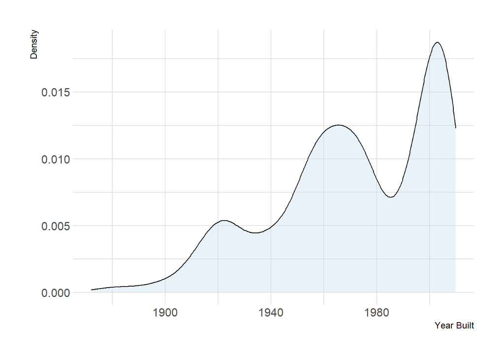

```r
ggplot(data=data, aes(x=data$YearBuilt)) +
    geom_density(alpha=.3, fill='lightblue') +
    theme_ipsum() +
    xlab('Year Built') +
    ylab('Density')
```

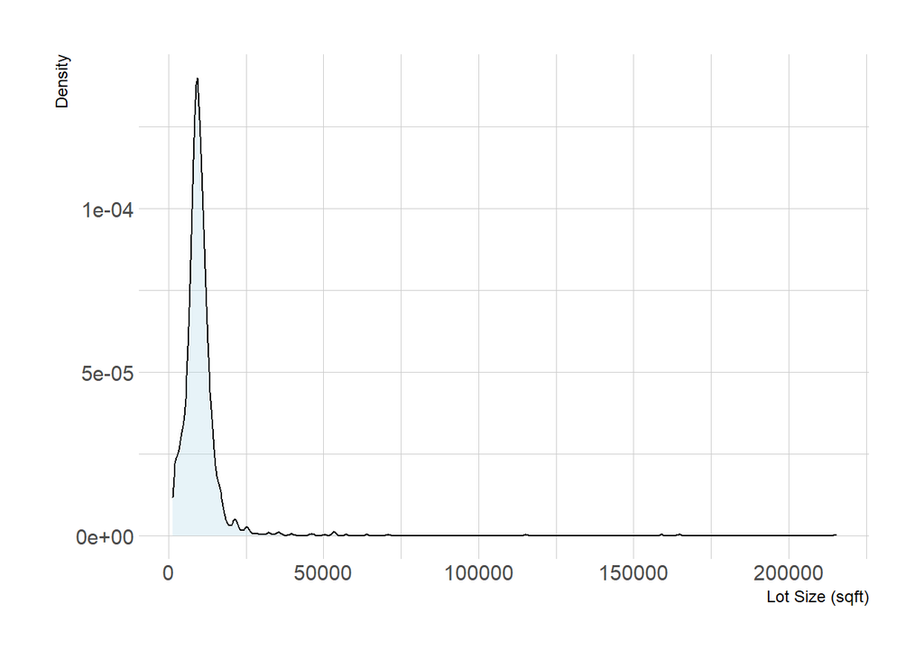

```r
ggplot(data=data, aes(x=data$LotArea)) +
    geom_density(alpha=.3, fill='lightblue') +
    theme_ipsum() +
    xlab('Lot Size (sqft)') +
    ylab('Density')
```

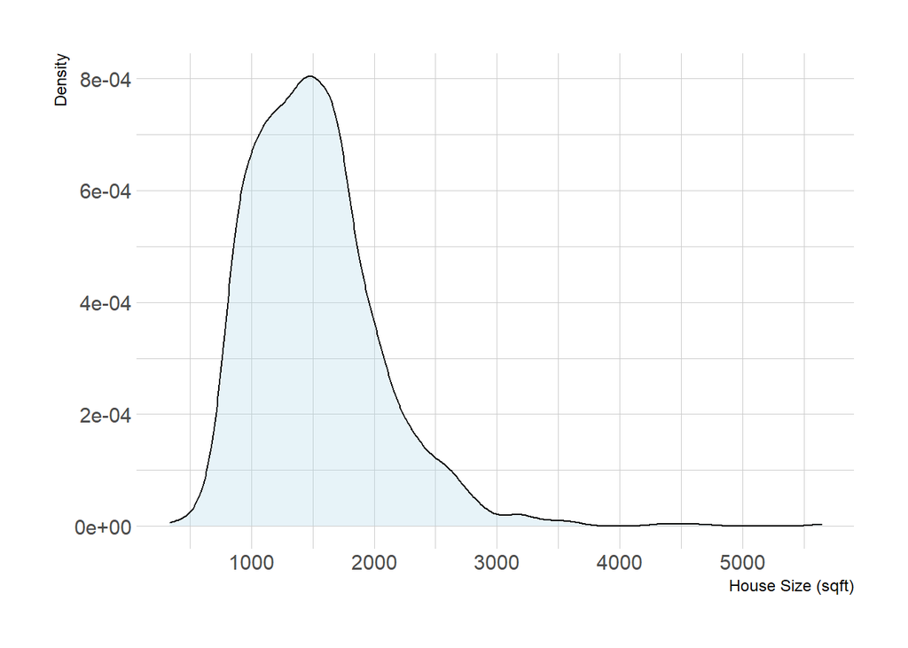

```r
ggplot(data=data, aes(x=data$GrLivArea)) +
    geom_density(alpha=.3, fill='lightblue') +
    theme_ipsum() +
    xlab('House Size (sqft)') +
    ylab('Density')
```

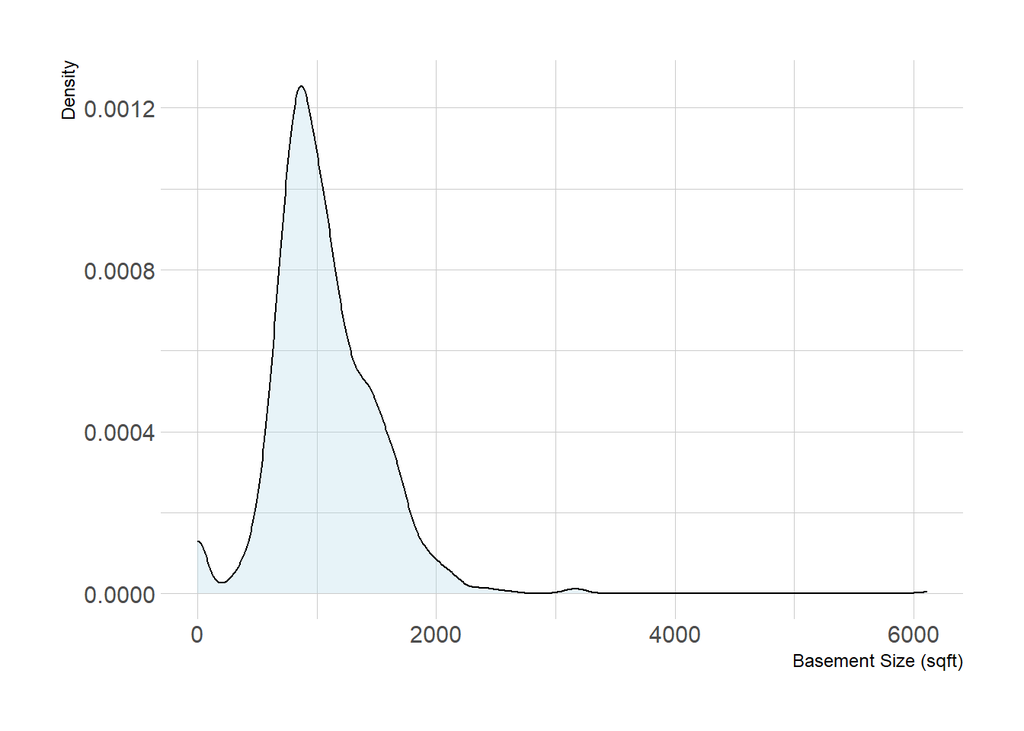

```r
ggplot(data=data, aes(x=data$TotalBsmtSF)) +
    geom_density(alpha=.3, fill='lightblue') +
    theme_ipsum() +
    xlab('Basement Size (sqft)') +
    ylab('Density')
```

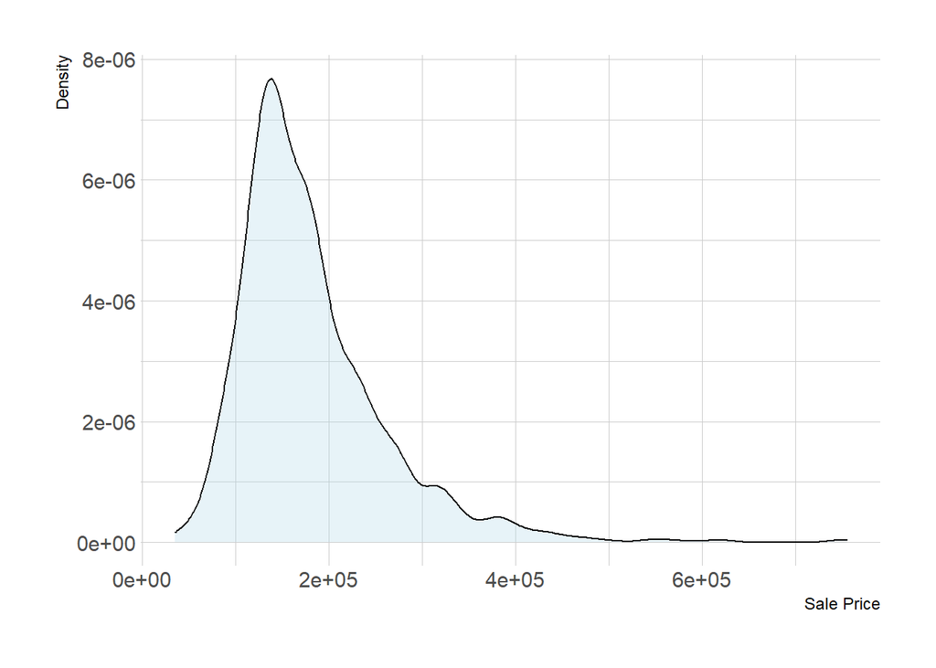

```r
ggplot(data=data, aes(x=data$SalePrice)) +
    geom_density(alpha=.3, fill='lightblue') +
    theme_ipsum() +
    xlab('Sale Price') +
    ylab('Density')
```

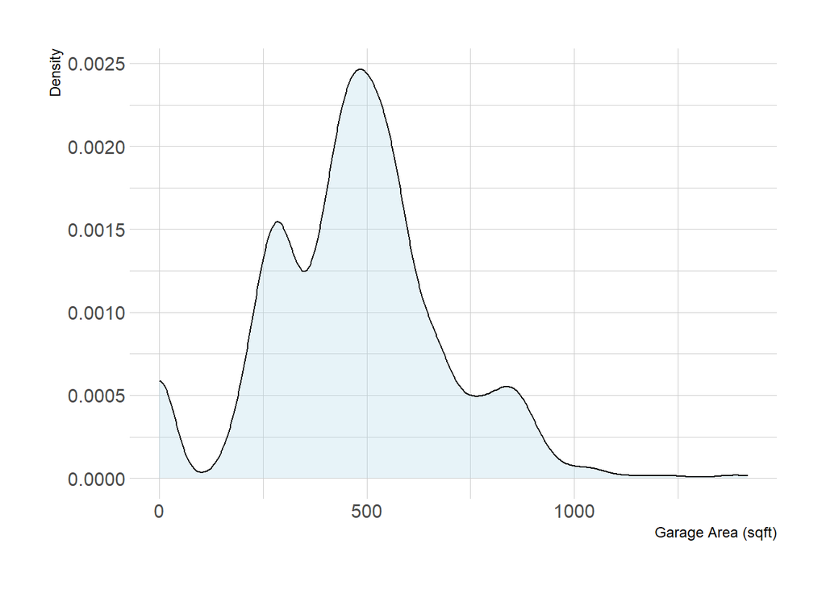

```r
ggplot(data=data, aes(x=data$GarageArea)) +
    geom_density(alpha=.3, fill='lightblue') +
    theme_ipsum() +
    xlab('Garage Area (sqft)') +
    ylab('Density')
```

## Scatter Plots

Below are scatter plots for each of the predictors and the outcome. These can will help to see any simple linear relationships. Some of these plots appear to display positive linear relationships with some obvious outliers.

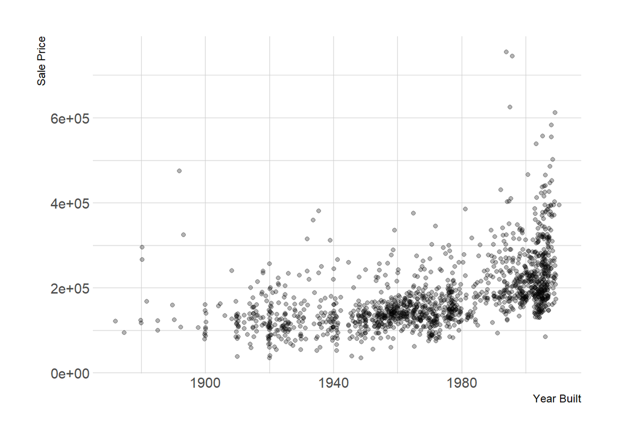

```r
ggplot(data=data, aes(x=data$YearBuilt, y=data$SalePrice)) +
    geom_jitter(alpha=.3) +
    theme_ipsum() +
    xlab('Year Built') +
    ylab('Sale Price')
```

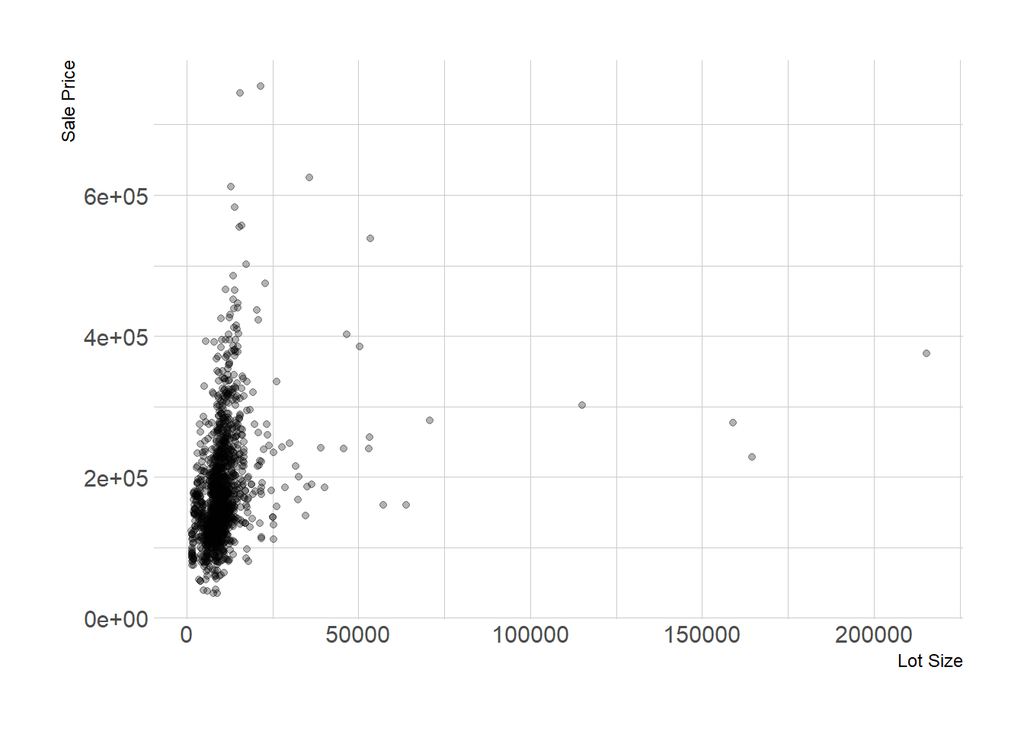

```r
ggplot(data=data, aes(x=data$LotArea, y=data$SalePrice)) +
    geom_jitter(alpha=.3) +
    theme_ipsum() +
    xlab('Lot Size') +
    ylab('Sale Price')
```

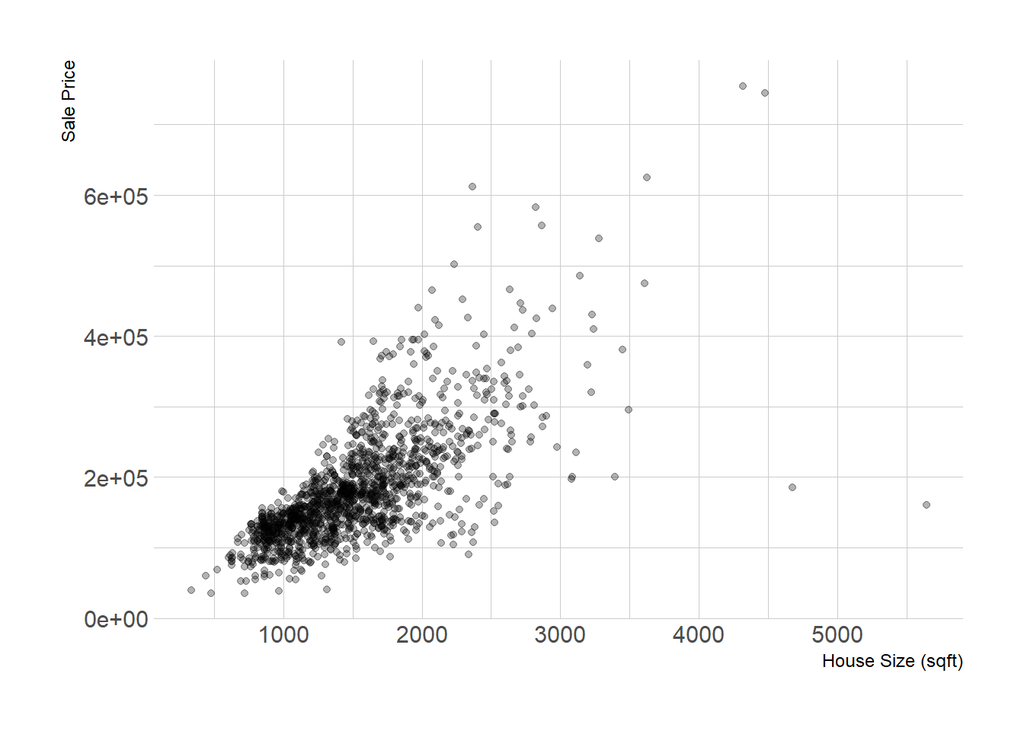

```r
ggplot(data=data, aes(x=data$GrLivArea, y=data$SalePrice)) +
    geom_jitter(alpha=.3) +
    theme_ipsum() +
    xlab('House Size (sqft)') +
    ylab('Sale Price')
```

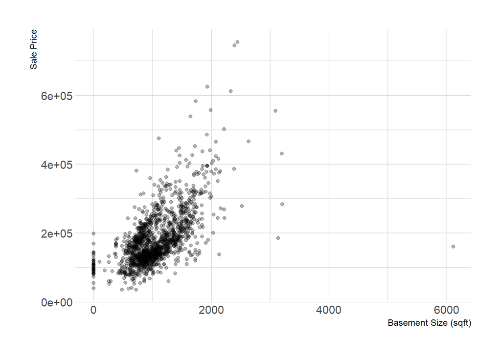

```r
ggplot(data=data, aes(x=data$TotalBsmtSF, y=data$SalePrice)) +
    geom_jitter(alpha=.3) +
    theme_ipsum() +
    xlab('Basement Size (sqft)') +
    ylab('Sale Price')
```

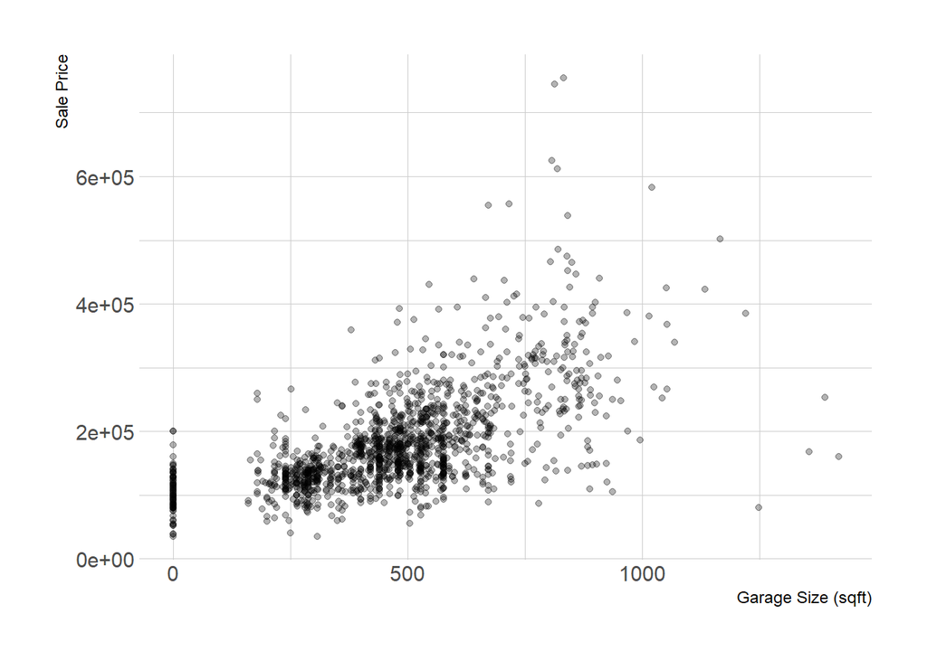

```r
ggplot(data=data, aes(x=data$GarageArea, y=data$SalePrice)) +
    geom_jitter(alpha=.3) +
    theme_ipsum() +
    xlab('Garage Size (sqft)') +
    ylab('Sale Price')
```

# Regression Model

```r
model <- lm(SalePrice ~ YearBuilt+LotArea+GrLivArea+TotalBsmtSF+GarageArea, data=data)
coef <- coefficients(model)
anova <- anova(model)
summary <- summary(model)
ci <- as_tibble(confint(model, level=0.95))
t <- as_tibble(summary[[4]])
```

```r
#Adding a variable column to table
Variable <- c('Intercept', 'Year Built', 'Lot Size', 'Living Square Ft', 'Basement Square Ft', 'Garage Area')
col.Variable2 <- data.frame(Variable)
summ3 <- cbind2(col.Variable2, t)
knitr::kable(summ3, align='lccrr')
```

| Variable | Estimate | Std. Error | t value | Pr(>\|t\|) |
| --- | --- | --- | --- | --- |
| Intercept | -1.405481e+06 | 8.395820e+04 | -16.740242 | 0.0000000 |
| Year Built | 7.135439e+02 | 4.333178e+01 | 16.466987 | 0.0000000 |
| Lot Size | 4.310335e-01 | 1.177541e-01 | 3.660455 | 0.0002608 |
| Living Square Ft | 7.147077e+01 | 2.543418e+00 | 28.100286 | 0.0000000 |
| Basement Square Ft | 3.576101e+01 | 3.160780e+00 | 11.313983 | 0.0000000 |
| Garage Area | 6.164436e+01 | 6.762310e+00 | 9.115872 | 0.0000000 |

The resulting regression model is
$$\hat{Y} = -1.4054807\times 10^{6} + 713.54X_{\mbox{YearBuilt}} + 0.43X_{\mbox{LotSize}} + 71.47X_{\mbox{HouseSize}} + 35.76X_{\mbox{BasemetnSize}} + 61.64X_{\mbox{GarageArea}}$$

# Confidence Interval for $\beta_i$

The confidence interval for year built is (628.54, 798.54).

The confidence interval for lot size is (0.2, 0.66).

The confidence interval for living square feet is (66.48, 76.46).

The confidence interval for basement square feet is (29.56, 41.96).

The confidence interval for garage area is (48.38, 74.91).

# Testing for Significance of Regression Line

**Hypotheses**

$H_0: \ \beta_1 = \beta_2 = \beta_3 = \beta_4 = \beta_5 = 0$  
$H_1: \ \mbox{at least one } \beta_i \ne 0$

**Test Statistic**

$F_0 = 732.22$.

*p*-value

$p < 0.0001$.

**Rejection Region**

Reject if $p < \alpha$, where $\alpha=0.05$.

**Conclusion and Interpretation**

Reject $H_0$. There is sufficient evidence to suggest that the regression line is significant.

# Testing for Significance of Individual Predictor

### Test for Year Built

**Hypotheses**

$H_0: \ \beta_1 = 0$  
$H_1: \ \beta_1 \ne 0$

**Test Statistic**

$t_0 = 16.47$.

*p*-value

$p < 0.0001$.

**Rejection Region**

Reject if $p < \alpha$, where $\alpha=0.05$.

**Conclusion and Interpretation**

Reject $H_0$. There is sufficient evidence to suggest that the year the home is built is a significant predictor of sale price.

### Test for Lot Size

**Hypotheses**

$H_0: \ \beta_1 = 0$  
$H_1: \ \beta_1 \ne 0$

**Test Statistic**

$t_0 = 3.66$.

*p*-value

$p = 0.0003$.

**Rejection Region**

Reject if $p < \alpha$, where $\alpha=0.05$.

**Conclusion and Interpretation**

Reject $H_0$. There is sufficient evidence to suggest that the lot size is a significant predictor of sale price.

### Test for Living Square Feet

**Hypotheses**

$H_0: \ \beta_1 = 0$  
$H_1: \ \beta_1 \ne 0$

**Test Statistic**

$t_0 = 28.1$.

*p*-value

$p < 0.0001$.

**Rejection Region**

Reject if $p < \alpha$, where $\alpha=0.05$.

**Conclusion and Interpretation**

Reject $H_0$. There is sufficient evidence to suggest that the living square feet is a significant predictor of sale price.

### Test for Basement Square Feet

**Hypotheses**

$H_0: \ \beta_1 = 0$  
$H_1: \ \beta_1 \ne 0$

**Test Statistic**

$t_0 = 11.31$.

*p*-value

$p < 0.0001$.

**Rejection Region**

Reject if $p < \alpha$, where $\alpha=0.05$.

**Conclusion and Interpretation**

Reject $H_0$. There is sufficient evidence to suggest that the basement square feet is a significant predictor of sale price.

### Test for Garage Area

**Hypotheses**

$H_0: \ \beta_1 = 0$  
$H_1: \ \beta_1 \ne 0$

**Test Statistic**

$t_0 = 9.12$.

*p*-value

$p < 0.0001$.

**Rejection Region**

Reject if $p < \alpha$, where $\alpha=0.05$.

**Conclusion and Interpretation**

Reject $H_0$. There is sufficient evidence to suggest that the garage size is a significant predictor of sale price.

# Adjusted $R^2$

$R_{adj}^2=0.71$; that is, approximately 71% of the variance in home sale price is explained by the current model (Year Built, Lot Size, Living Square Ft, Basement Square Ft, and Garage Size).

# Model Assumptions

Lets verify that the residuals have a normal distribution with a mean of zero and a constant variance.

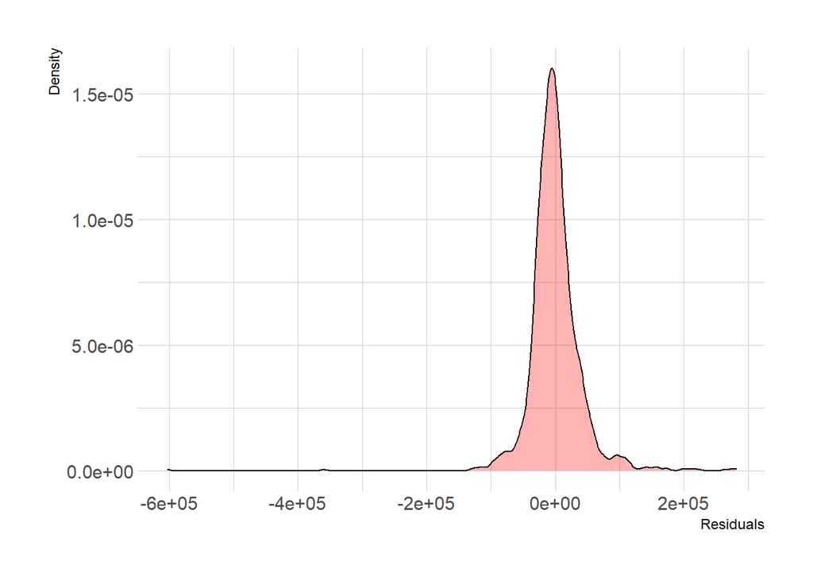

```r
res <- data.frame(summary$residuals)
ggplot(data=res, aes(x=res$summary.residuals)) +
    geom_density(alpha=.3, fill='red') +
    theme_ipsum() +
    xlab('Residuals') +
    ylab('Density')
```

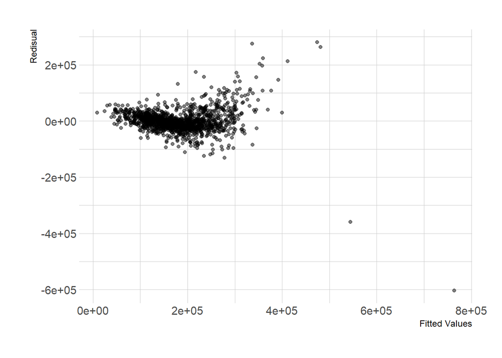

```r
ggplot(data=data, aes(x=model$fitted.values, y=res$summary.residuals)) +
    geom_point(alpha=.5) +
    theme_ipsum() +
    xlab('Fitted Values') +
    ylab('Redisual')
```

The residual distribution is approximately normal with a mean of zero. However, the variance does not appear to be constant. This means that the predictions might not be trustworthy. The variance plot shows that the error is much higher and not consistent for higher sales prices, notice the cone like shape.

# Analysis of Results

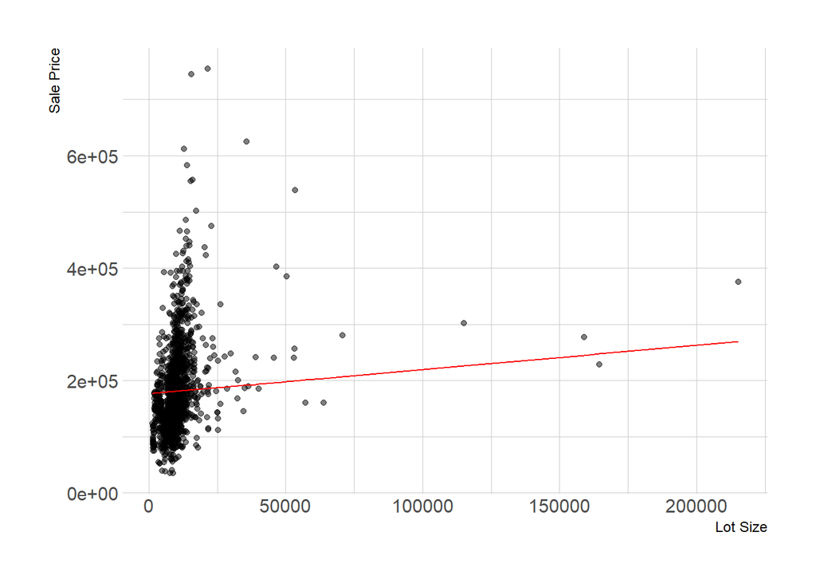

```r
data$pred_price_lotSize <- coef[[1]] + coef[[2]]*mean(data$YearBuilt) + coef[[3]]*data$LotArea + coef[[4]]*mean(data$GrLivArea) + coef[[5]]*mean(data$TotalBsmtSF) + coef[[6]]*mean(data$GarageArea)
ggplot(data=data, aes(x=data$LotArea, y=data$SalePrice)) +
    geom_point(alpha=.5) +
    theme_ipsum() +
    xlab('Lot Size') +
    ylab('Sale Price')+
    geom_line(aes(y = data$pred_price_lotSize), color = "red", linetype = "solid")
```

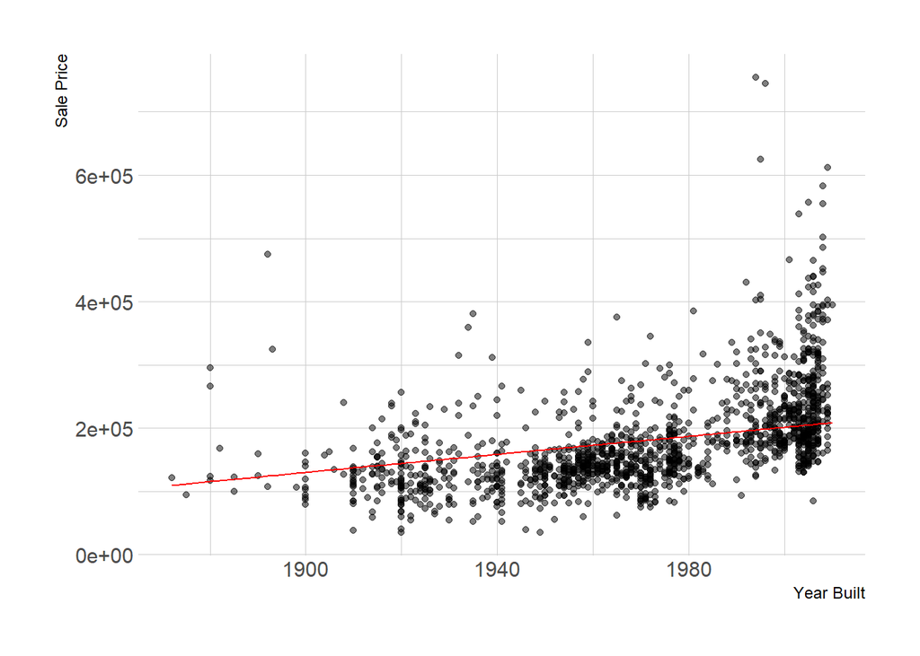

```r
data$pred_price_yrBuilt <- coef[[1]] + coef[[2]]*data$YearBuilt + coef[[3]]*mean(data$LotArea) + coef[[4]]*mean(data$GrLivArea) + coef[[5]]*mean(data$TotalBsmtSF) + coef[[6]]*mean(data$GarageArea)
ggplot(data=data, aes(x=data$YearBuilt, y=data$SalePrice)) +
    geom_point(alpha=.5) +
    theme_ipsum() +
    xlab('Year Built') +
    ylab('Sale Price')+
    geom_line(aes(y = data$pred_price_yrBuilt), color = "red", linetype = "solid")
```

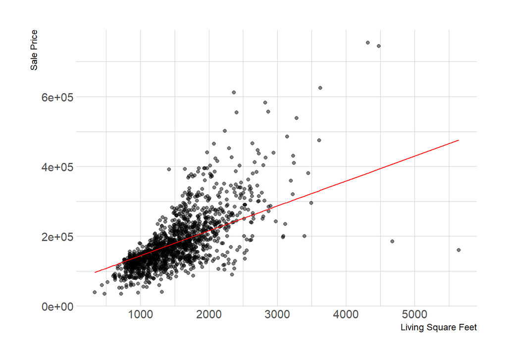

```r
data$pred_price_living <- coef[[1]] + coef[[2]]*mean(data$YearBuilt) + coef[[3]]*mean(data$LotArea) + coef[[4]]*data$GrLivArea + coef[[5]]*mean(data$TotalBsmtSF) + coef[[6]]*mean(data$GarageArea)
ggplot(data=data, aes(x=data$GrLivArea, y=data$SalePrice)) +
    geom_point(alpha=.5) +
    theme_ipsum() +
    xlab('Living Square Feet') +
    ylab('Sale Price')+
    geom_line(aes(y = data$pred_price_living), color = "red", linetype = "solid")
```

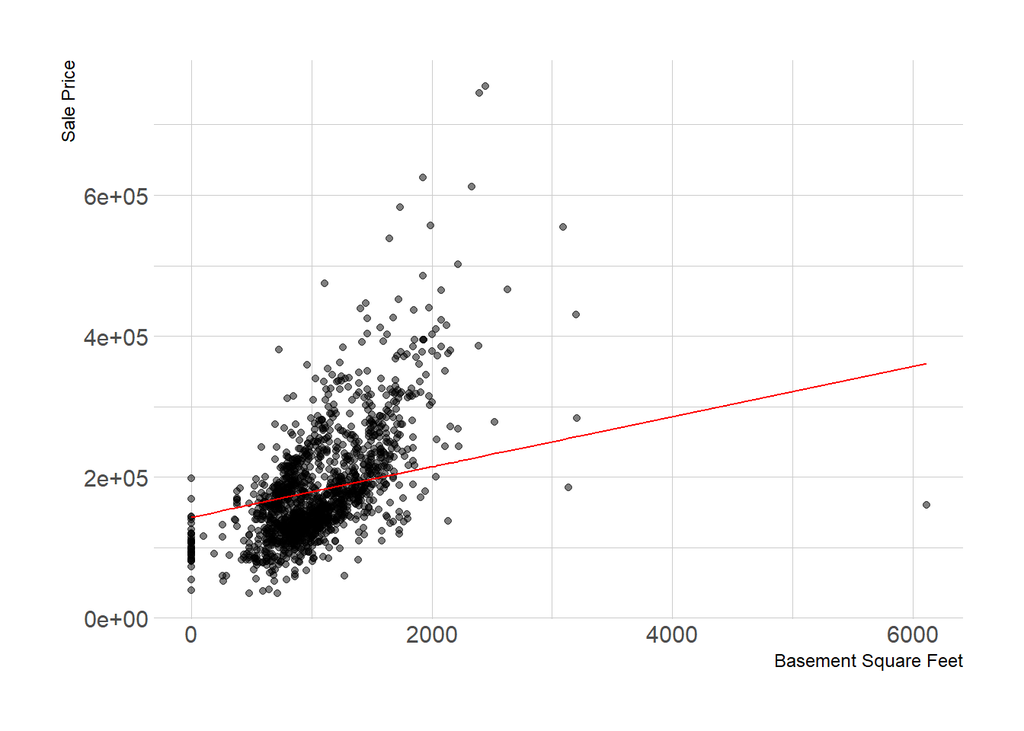

```r
data$pred_price_basement <- coef[[1]] + coef[[2]]*mean(data$YearBuilt) + coef[[3]]*mean(data$LotArea) + coef[[4]]*mean(data$GrLivArea) + coef[[5]]*data$TotalBsmtSF + coef[[6]]*mean(data$GarageArea)
ggplot(data=data, aes(x=data$TotalBsmtSF, y=data$SalePrice)) +
    geom_point(alpha=.5) +
    theme_ipsum() +
    xlab('Basement Square Feet') +
    ylab('Sale Price')+
    geom_line(aes(y = data$pred_price_basement), color = "red", linetype = "solid")
```

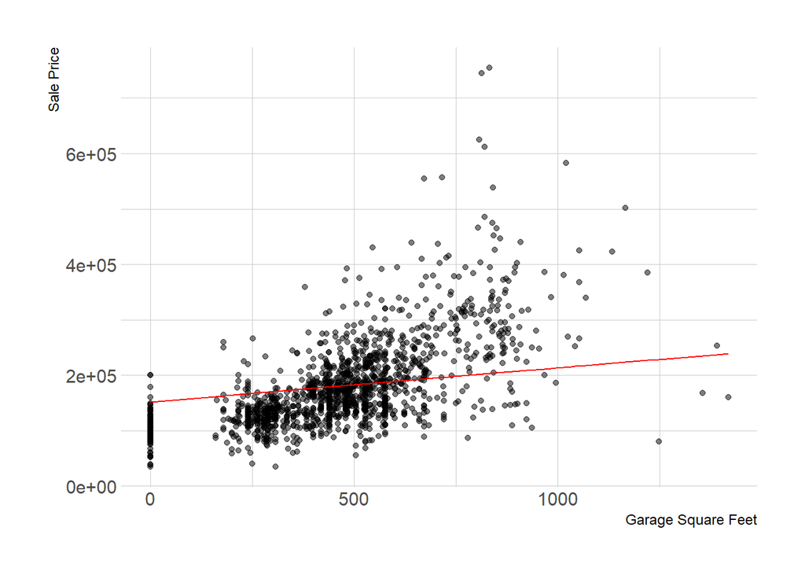

```r
data$pred_price_GarageArea <- coef[[1]] + coef[[2]]*mean(data$YearBuilt) + coef[[3]]*mean(data$LotArea) + coef[[4]]*mean(data$GrLivArea) + coef[[5]]*mean(data$TotalBsmtSF) + coef[[6]]*data$GarageArea
ggplot(data=data, aes(x=data$GarageArea, y=data$SalePrice)) +
    geom_point(alpha=.5) +
    theme_ipsum() +
    xlab('Garage Square Feet') +
    ylab('Sale Price')+
    geom_line(aes(y = data$pred_price_GarageArea), color = "red", linetype = "solid")
```

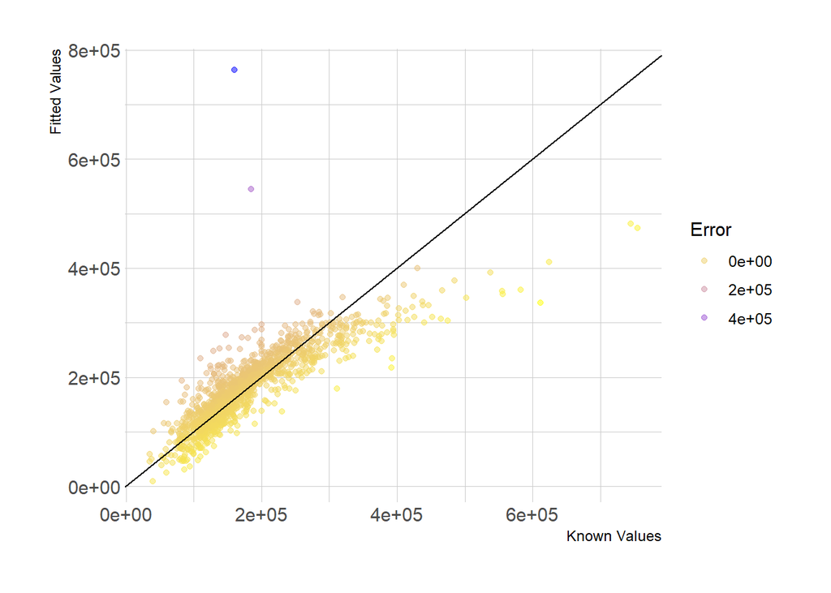

```r
#Plot fitted values vs known values.
get_err <- lm(model$fitted.values ~ data$SalePrice)

ggplot(data=data, aes(x=data$SalePrice, y=model$fitted.values, color=get_err$residuals)) +
    geom_jitter(alpha=.5) +
    geom_abline(intercept = 0, slope = 1) +
    theme_ipsum() +
    xlab('Known Values') +
    ylab('Fitted Values') +
    scale_color_gradient(low = "yellow", high = "blue", na.value = NA) +
    guides(color=guide_legend(title="Error"))
```

I wanted a way to look at the accuracy of the model. So I used the known values to model the predicted values and get the error. Theoretically, if the model is 100% accurate the scatter plot should mimic y=x. The further away a dot is from the line, the higher the error.